# Causal Inference II

Chelsea Parlett-Pelleriti

# Review

## Core DAG Paths

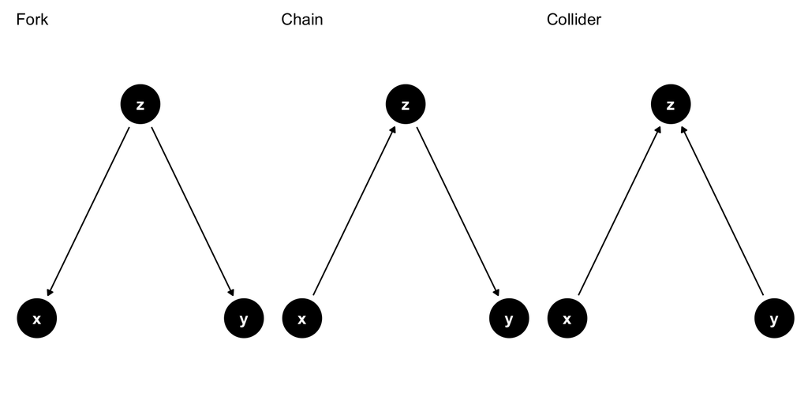

**Fork**: `z` is a *confounder* (condition)

**Chain**: `z` is a *mediator* (maybe condition)

**Collider**: `z` is a *collider* (don’t condition)

# Adjustment

**Goal**: close back door paths by **controlling for** an appropriate adjustment set.

- How do we “control for?”
  - covariates
  - subsetting
  - matching
  - propensity scores
  - regression discontinuity
  - diff-in-diff
  - instrumental variables

## Covariates

```r
set.seed(12938)
n <- 250
logit <- function(x){
  return(1/(1 + exp(-x)))
}

extra_curriculars <- rnorm(n)
exam_scores <- rnorm(n)
acceptance <- rbinom(n, size = 1, prob = logit(1.6*extra_curriculars + exam_scores*2))

df <- data.frame(extra_curriculars, exam_scores, acceptance)

# build reg
lin_reg <- lm(exam_scores ~ extra_curriculars + acceptance,
    data = df) %>% summary()

lin_reg$coef %>% round(4)
```

```
                  Estimate Std. Error t value Pr(>|t|)
(Intercept)        -0.6392     0.0783 -8.1622    0e+00
extra_curriculars  -0.2280     0.0579 -3.9402    1e-04
acceptance          1.2703     0.1187 10.7038    0e+00
```

## Coefficient Interpretation in GLMs

$$\beta = \rho_{x,y} \cdot \frac{\sigma_y}{\sigma_x}$$

In simple linear regression, we can prove via OLS or MLE that the coefficient for variable $x$ is a scaled version of the correlation $\rho_{x,y}$

But what about when there are $\mathbf{x} = \left(x_1, x_2, ..., x_n \right)$?

## Coefficient Interpretation in GLMs

```r
# simulate data
n <- 10000
x1 <- rnorm(n)
x2 <- rnorm(n, 0 + 0.5*x1)
y <- rnorm(n, x1*2 + 0.4*x2 - 2)
df <- data.frame(y = y, x1 = x1, x2 = x2)

# regular model
lm(y ~ x1 + x2, data = df)
```

```
Call:
lm(formula = y ~ x1 + x2, data = df)

Coefficients:
(Intercept)           x1           x2
    -1.9826       1.9881       0.4043
```

## Coefficient Interpretation in GLMs

```r
# regular model
lm(y ~ x1 + x2, data = df)
```

```
Call:
lm(formula = y ~ x1 + x2, data = df)

Coefficients:
(Intercept)           x1           x2
    -1.9826       1.9881       0.4043
```

```r
# naive approach
cor(x1,y) * sd(y)/sd(x1)
```

```
[1] 2.188284
```

```r
cor(x2,y) * sd(y)/sd(x2)
```

```
[1] 1.204316
```

## Coefficient Interpretation in GLMs

**correlation:** the correlation between $y$ and $x1$

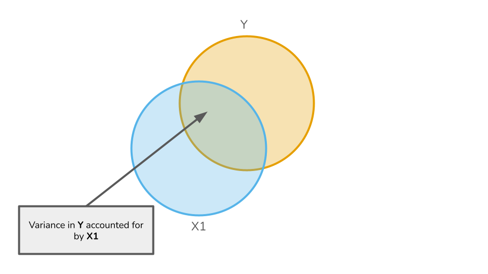

## Coefficient Interpretation in GLMs

**semi-partial correlation:** the correlation between $y$ and $x1$, after subtracting the influence of $x2$ on $x1$

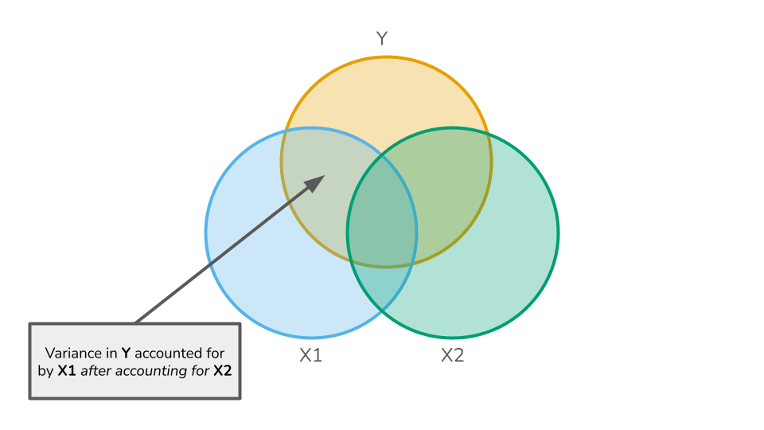

## Coefficient Interpretation in GLMs

```r
# regular model
lm(y ~ x1 + x2, data = df)
```

```
Call:
lm(formula = y ~ x1 + x2, data = df)

Coefficients:
(Intercept)           x1           x2
    -1.9826       1.9881       0.4043
```

```r
# naive approach
cor(x1,y) * sd(y)/sd(x1)
```

```
[1] 2.188284
```

```r
cor(x2,y) * sd(y)/sd(x2)
```

```
[1] 1.204316
```

```r
# spc approach
# calculate resid
resx2 <- lm(x2~x1,data = df)$residuals
resx1 <- lm(x1~x2,data = df)$residuals

cor(resx1,y) * sd(y)/sd(resx1)
```

```
[1] 1.988138
```

```r
cor(resx2,y) * sd(y)/sd(resx2)
```

```
[1] 0.4043375
```

## Coefficient Interpretation in GLMs

```r
# simulate data
n <- 10000
x1 <- rnorm(n)
x2 <- rnorm(n, 0 + 0.5*x1)
x3 <- rnorm(n, 0 + 0.5*x1 - 0.1*x2)
y <- rnorm(n, x1*2 + 0.4*x2 + 0.2*x3 - 2)
df <- data.frame(y = y, x1 = x1, x2 = x2)

# regular model
lm(y ~ x1 + x2 + x3, data = df)
```

```
Call:
lm(formula = y ~ x1 + x2 + x3, data = df)

Coefficients:
(Intercept)           x1           x2           x3
    -2.0028       2.0050       0.4085       0.1900
```

```r
# naive approach
cor(x1,y) * sd(y)/sd(x1)
```

```
[1] 2.296495
```

```r
cor(x2,y) * sd(y)/sd(x2)
```

```
[1] 1.236363
```

```r
cor(x3,y) * sd(y)/sd(x3)
```

```
[1] 0.9591191
```

```r
# spc approach
# calculate resid
resx3 <- lm(x3~x1 + x2,data = df)$residuals

cor(resx3,y) * sd(y)/sd(resx3)
```

```
[1] 0.1900424
```

# A Note on “Controlling For”

💡 when we say we want to “control for” a variable, what we’d ideally like is to compare subjects who are *exactly the same* in that variable.

😦 But we often can’t get that data easily

⬇️ All the methods we’re discussing today allow us to *get as closer* to that ideal when it’s not possible. For each method, ask yourself “*how does this make the groups I’m comparing more similar?*”

## Subsetting

```r
n <- 250
logit <- function(x){
  return(1/(1 + exp(-x)))
}

extra_curriculars <- rnorm(n)
exam_scores <- rnorm(n)
acceptance <- rbinom(n, size = 1,
                     prob = logit(1.6*extra_curriculars + exam_scores*2))

df <- data.frame(extra_curriculars, exam_scores, acceptance)

# build reg
lin_reg <- lm(exam_scores ~ extra_curriculars,
    data = df %>% filter(acceptance == 1)) %>% summary()

lin_reg$coef %>% round(4)
```

```
                  Estimate Std. Error t value Pr(>|t|)
(Intercept)         0.6840     0.0841  8.1291   0.0000
extra_curriculars  -0.2123     0.0799 -2.6557   0.0089
```

## Matching

**Matching** creates two groups that are similar based on a set of **covariates**.

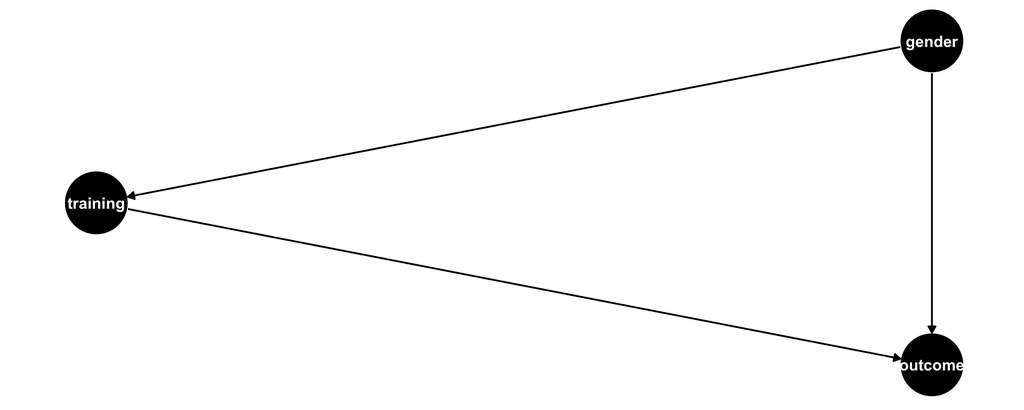

example from: https://theeffectbook.net/ch-Matching.html

## Matching

| Gender | Training | Job | No Job | Total |
| --- | --- | --- | --- | --- |
| **Man** | Yes | 60 | 20 | *80* |
| **Woman** | Yes | 12 | 8 | *20* |
| **Man** | No | 350 | 150 | *500* |
| **Woman** | No | 275 | 225 | *500* |
| **Total** |  | *697* | *403* | *1100* |

$(60 + 12)/100 = 0.72$ of people in the training group get jobs, and $(350 + 275)/1000 = 0.625$ of people in the control group get jobs. But…

## Matching

**Gender** is a confounder of the effect of **training** on **outcome**.

💡 Create two groups where proportion of **gender** doesn’t vary

**Naive Option:** throw away data 🗑️ 😠

## Matching

**Training Group**: 80% men, 20% women

**Population**: 50% men, 50% women

💡 Find **weights** for each observation that make **training** **group** and **population** comparable

## Matching

| Gender | Training | Job | No Job | Total |
| --- | --- | --- | --- | --- |
| **Man** | Yes | 60 | 20 | *80* |
| **Woman** | Yes | 12 | 8 | *20* |
| **Man** | No | 350 | 150 | *500* |
| **Woman** | No | 275 | 225 | *500* |
| **Total** |  | *697* | *403* | *1100* |

$w = 1$ for those in **training** group, $w_{man} = \frac{80}{500}$ and $w_{woman} = \frac{20}{500}$ for **control** group

## Matching

Now:

$$\text{prop man}_{\text{no train}} = \frac{0.16 \times500}{0.16 \times500 + 0.04 \times 500} = 0.8$$

$$\text{prop man}_{\text{train}} = \frac{1 \times80}{1 \times80 + 1 \times 20} = 0.8$$

💡we’ve re-weighted each sample so that men comprise 80% of the sample!

## Matching

Originally $(60 + 12)/100 = 0.72$ of people in the **training** group get jobs, and $(350 + 275)/1000 = 0.625$ of people in the **control** group get jobs.

Now, $\frac{(1 \times60 + 1\times12)}{(1 \times80 + 1\times 20)} = 0.72$ of people in the **training** group got jobs and $\frac{(0.16 \times 350 + 0.04 \times 275)}{0.16 \times500 + 0.04 \times 500} = 0.67$ of people in the **control** group got jobs.

There’s *less* of an impact once we “control for” the backdoor path of **gender**.

## Matching

**select matches** vs **weighted sample**

We could also select members of the control group who *match* each member of the treatment group: 👯

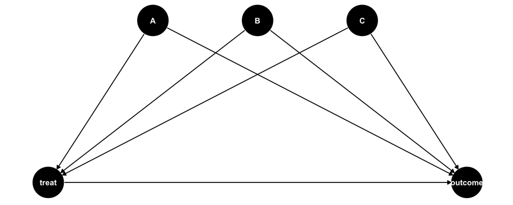

## Matching

Since **A, B,** and **C** are confounders of the effect of **treat** on **outcome**, we want to get groups that *match* on **A, B,** and **C**.

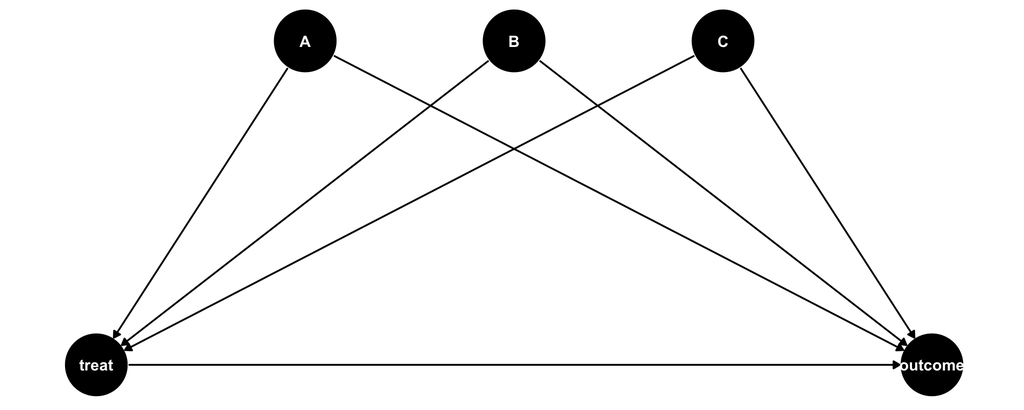

## Matching

- **Distance Matching**: observations are similar if they are “similar” in **A, B,** and **C**
- **Propensity Score Matching**: observations are similar if they have a “similar” probability of being treated

## Propensity Scores

In non experiments, **confounders** can influence both **exposure** and **outcome**

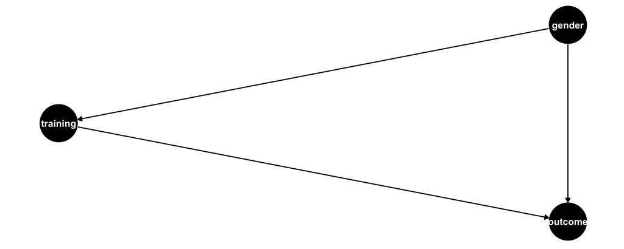

But what if we could *adjust for* your probability of being treated?

## Propensity Scores

**propensity score**: probability of being exposed *given* some set of covariates $\mathbf{c}$

Rosenbaum and Rubin (1983) suggest that controlling for *propensity scores* can give you an unbiased estimate of the effect of **exposure** on **outcome** if:

- There are no unmeasured **confounders**
- Every subject has a **non-zero** probability of getting exposed

from: https://www.r-causal.org/chapters/08-building-ps-models

## Propensity Scores

Propensity scores allow us to “simulate” what would happen if they were treated/not treated.

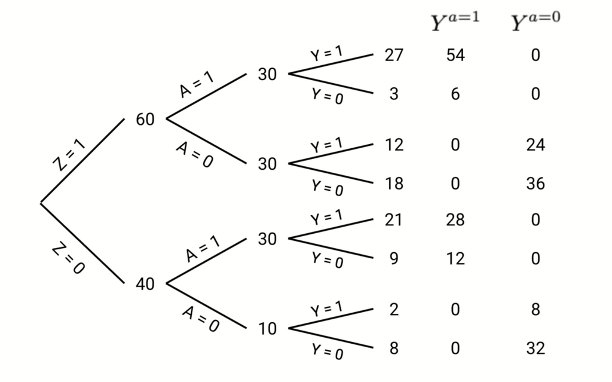

from:https://www.youtube.com/watch?v=PfLYPt9ur4g

## Propensity Scores

In this example, $Z$ impacts the probability that you’re treated ($P(treat | z = 1)$ = 50% vs $P(treat | z = 0)$ = 75%).

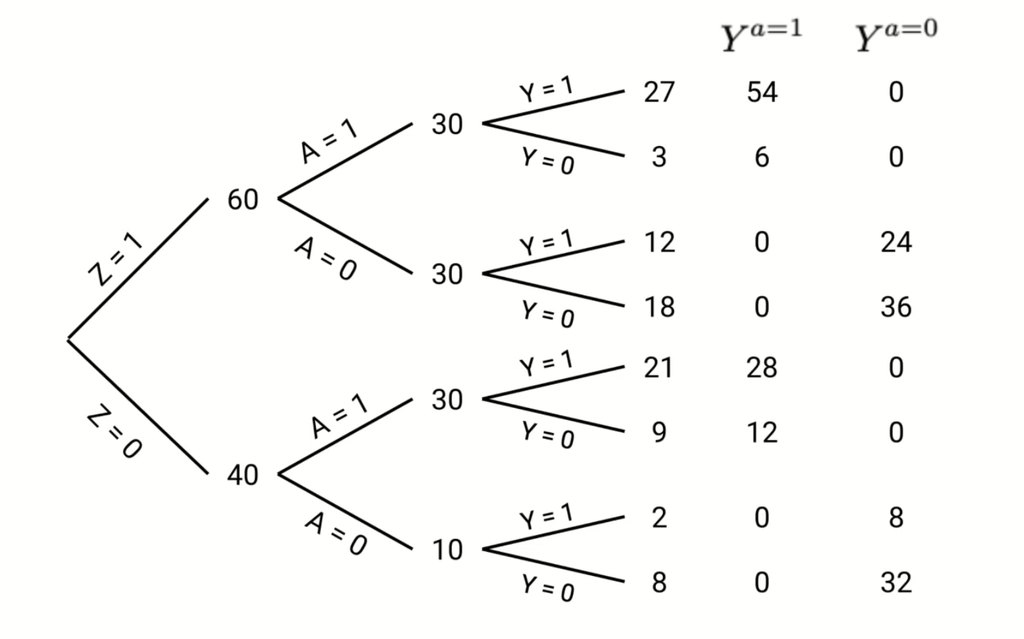

from:https://www.youtube.com/watch?v=PfLYPt9ur4g

## Propensity Score Generation

want: $p\left (\text{exposure = 1} | \mathbf{c} \right)$

that looks a lot like what a **logistic regression** of `exposure ~ c` estimates…

## Propensity Score Generation

```r
# from: https://www.hsph.harvard.edu/miguel-hernan/wp-content/uploads/sites/1268/2024/04/hernanrobins_WhatIf_26apr24.pdf
# qsmk -> wt82_71

nhefs <- read.csv("../../Data/nhefs.csv") %>%
  select('wt82_71', 'qsmk', 'sex', 'age', 'race', 'education', 'wt71', 'active', 'exercise', 'smokeintensity', 'smokeyrs')

nhefs %>% head(3)
```

```
     wt82_71 qsmk sex age race education  wt71 active exercise smokeintensity
1 -10.093960    0   0  42    1         1 79.04      0        2             30
2   2.604970    0   0  36    0         2 58.63      0        0             20
3   9.414486    0   1  56    1         2 56.81      0        2             20
  smokeyrs
1       29
2       24
3       26
```

## Propensity Score Generation

How **likely** is it that someone will quit smoking?

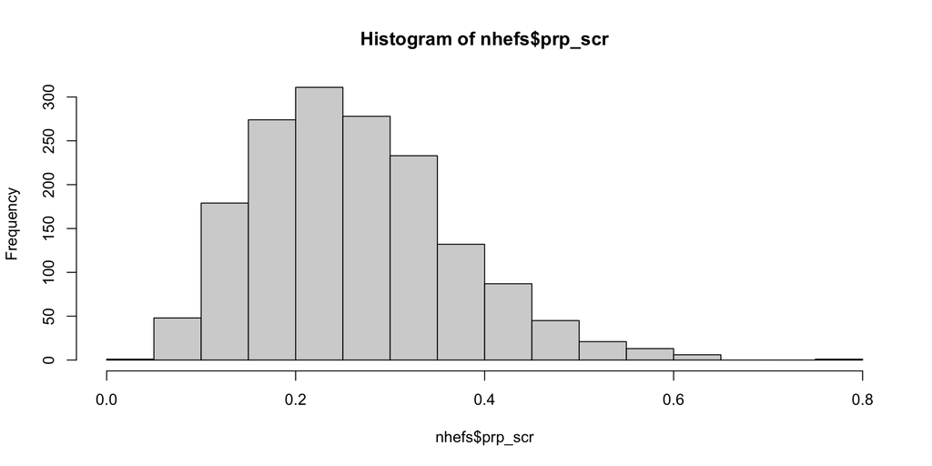

```r
lr <- glm(qsmk ~ sex + age + race + education + wt71 +
            active + exercise+ smokeintensity + smokeyrs,
          data = nhefs,
          family = "binomial")

prp_scr <- predict(lr, nhefs, type = "response")

nhefs <- nhefs %>% mutate(prp_scr = prp_scr)
hist(nhefs$prp_scr)
```

## Inverse Probability Weighting

$$w_A = \frac{1}{p(A|\mathbf{c})} = \frac{\text{treat}}{\text{propensity}} + \frac{1-\text{treat}}{1-\text{propensity}}$$

where $A$ is the treatment ($A = 0$ did not quit smoking, $A=1$ did quit smoking). For people who did quit, the weights are $w_{A = 1} = \frac{1}{p(A = 1 | \mathbf{c})}$ and for people who did **not** quit, the weights are $w_{A = 0} = \frac{1}{p(A = 0 | \mathbf{c})}$.

**Note:** the more *unlikely* it is that someone should be in their treatment group, the *higher* the weight that subject has.

## Inverse Probability Weighting

```r
 nhefs <- nhefs %>%
   mutate(ipw = (qsmk / prp_scr) + ((1 - qsmk) / (1 - prp_scr)))

 nhefs %>%
   select(qsmk, prp_scr, ipw) %>%
   head(4)
```

```
  qsmk   prp_scr      ipw
1    0 0.1237615 1.141242
2    0 0.1896523 1.234038
3    0 0.1805699 1.220360
4    0 0.3176696 1.465566
```

## Inverse Probability Weighting

```r
biased_lm <- lm(wt82_71 ~ qsmk,
                  data = nhefs)
unbiased_lm <- lm(wt82_71 ~ qsmk,
                  data = nhefs,
                  weights = ipw)
# print out
summary(biased_lm)$coef
```

```
            Estimate Std. Error  t value     Pr(>|t|)
(Intercept) 1.984498  0.2288285 8.672423 1.040008e-17
qsmk        2.540581  0.4510799 5.632220 2.105798e-08
```

```r
summary(unbiased_lm)$coef
```

```
            Estimate Std. Error  t value     Pr(>|t|)
(Intercept) 1.776923  0.2863833 6.204703 7.002251e-10
qsmk        3.322501  0.4077726 8.147926 7.498911e-16
```

Note: there’s a large about of bias in the estimate if we don’t control for potential confounders!

## Diff-in-Diff

[figure not shown]

## Diff-in-Diff

Just kidding.

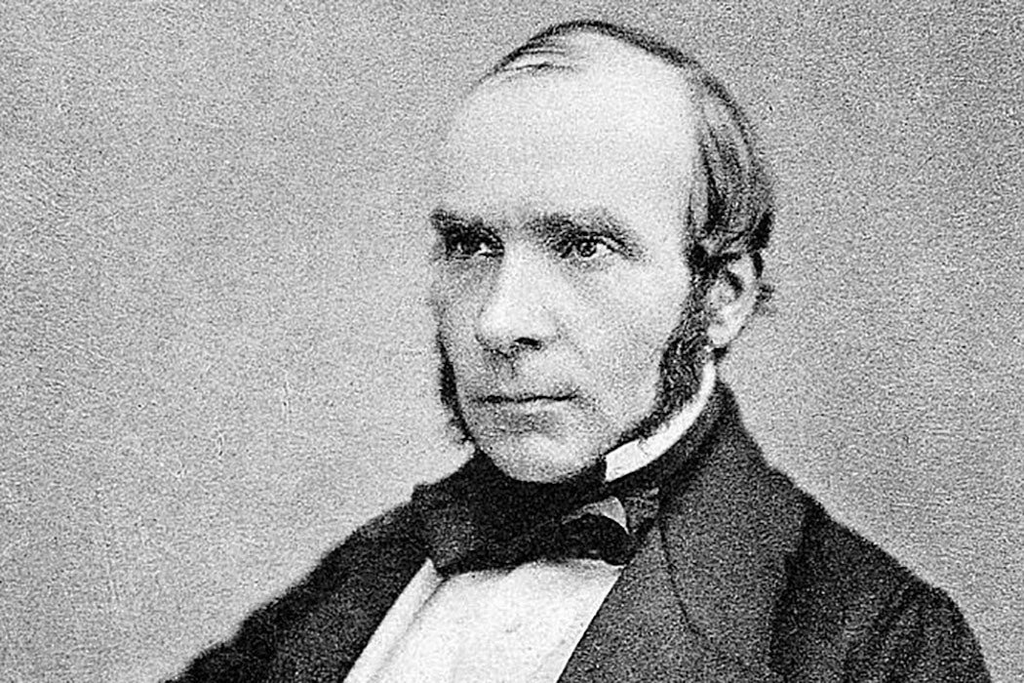

## Diff-in-Diff

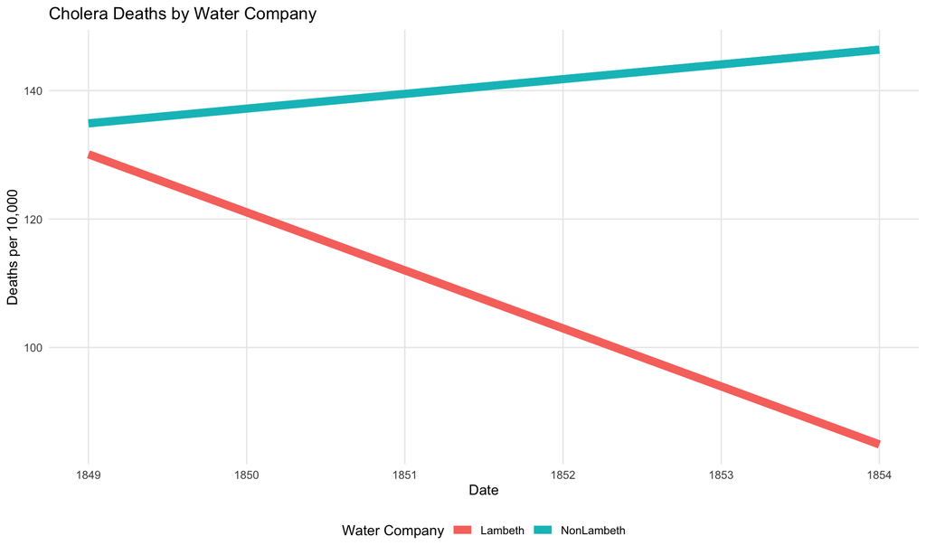

## Diff-in-Diff

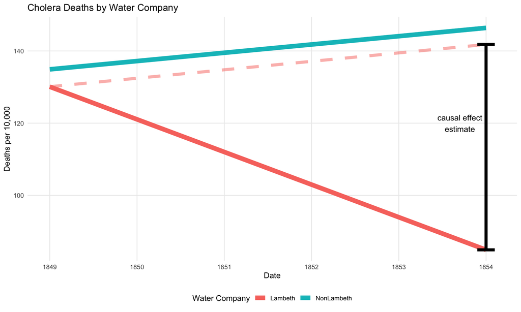

## Diff-in-Diff

- **Assumptions**: Parallel Trends

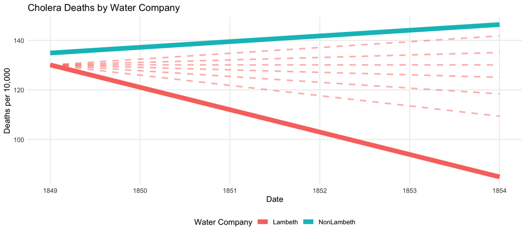

## Diff-in-Diff

- Checking Parallel Trends Assumption

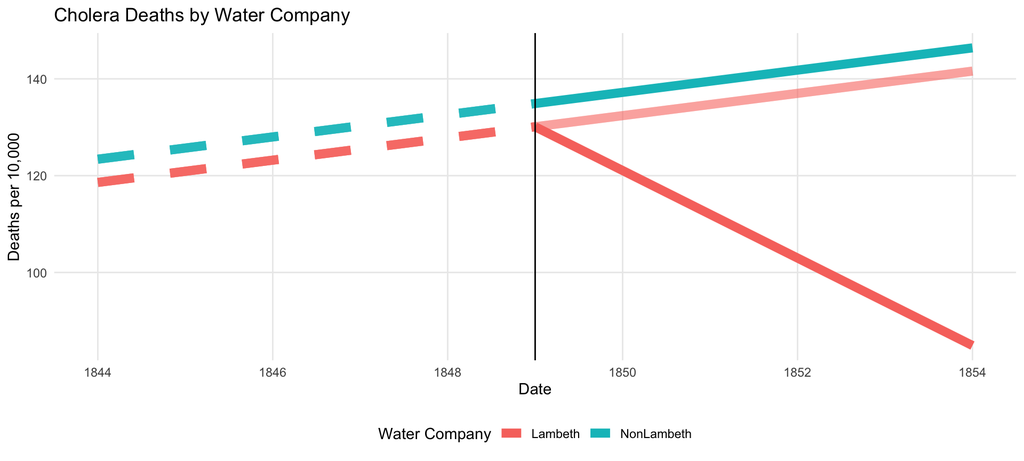

## Diff-in-Diff: Marketing Example

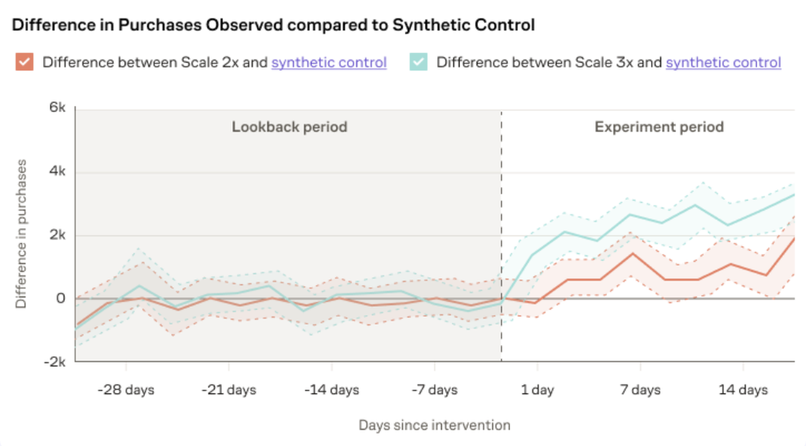

from: https://www.geteppo.com/eppo-geolift-for-data

## Diff-in-Diff: Simple

$$\underbrace{\left(After_c - Before_c\right)}_\text{diff for control} - \underbrace{\left(After_t - Before_t\right)}_\text{diff for treatment} = DiD$$

## Diff-in-Diff: Regression

$$\hat{y} = \beta_0 + \beta_1\text{treat} + \beta_2\text{time} + \beta_3\text{treat}\times\text{time}$$

Note: The regression estimates the 4 needed means, and gives you standard errors to quantify uncertainty.

## Regression Discontinuity

```r
n <- 1000
income_in_k <- rnorm(n,70,20)
medicaid <- income_in_k<= 69
health_quality <- -15 + 0.2*income_in_k + 2*medicaid + rnorm(n,0,2)
```

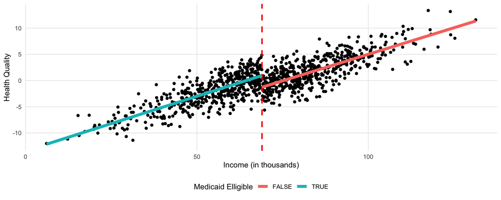

## Regression Discontinuity

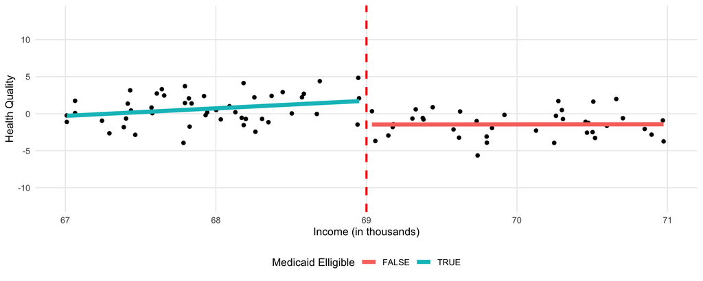

## Regression Discontinuity

- **Running Variable**: determines whether you’re above or below cutoff
- **Cutoff**: threshold for getting treatment
- **Bandwidth**: how wide around the cutoff to look

## Regression Discontinuity

$$\hat{y} = \beta_0 + \beta_1 \text{(running - cutoff)} + \beta_2 \text{treat} + \beta_3 \text{(running - cutoff)} \times \text{treat}$$

- $\beta_0 + \beta_2$: predicted value at the cutoff for **treated** subjects
- $\beta_0$ : predicted value at the cutoff for **untreated** subjects

## Regression Discontinuity

```r
df <- df %>%
  mutate(r_minus_c = income_in_k - 69)
rd <- lm(health_quality ~ r_minus_c + medicaid + r_minus_c:medicaid,
         data = df)
summary(rd)$coef
```

```
                           Estimate  Std. Error    t value      Pr(>|t|)
(Intercept)            -1.276497576 0.148072135 -8.6207819  2.582548e-17
r_minus_c               0.202532345 0.007623427 26.5670984 5.401900e-118
medicaidTRUE            2.229709121 0.205185078 10.8668191  4.505584e-26
r_minus_c:medicaidTRUE  0.005996821 0.010575487  0.5670492  5.708085e-01
```

## Instrumental Variables

Sometimes, it’s inconvenient to randomly assign a treatment. What if we could find another variable (**instrument**) that is uncorrelated with outcome, but causes treatment.

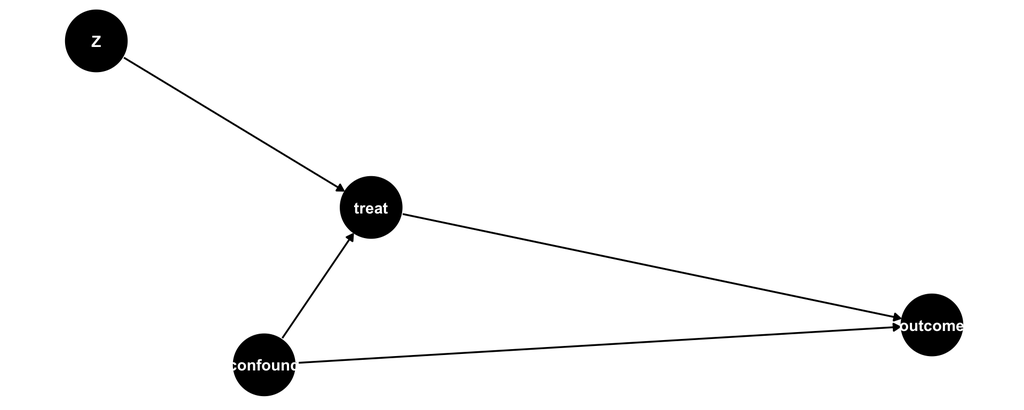

## Instrumental Variables

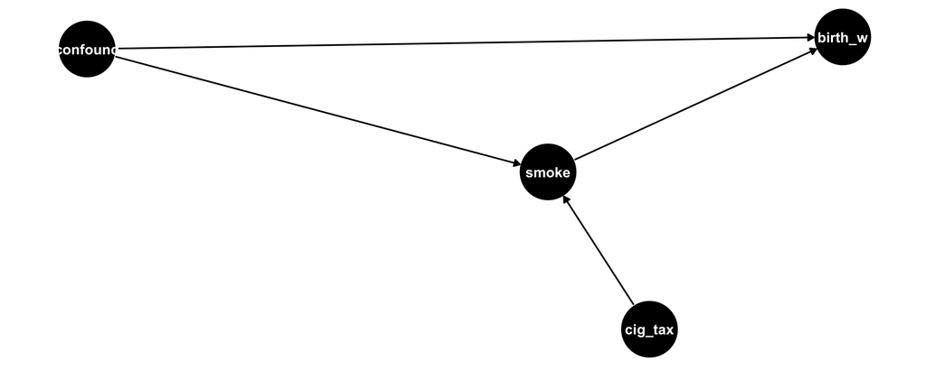

## Instrumental Variables

A real life example from my work!

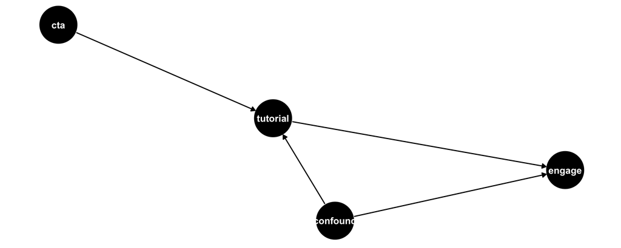

## Instrumental Variables

A good instrument must be:

- Correlated with treatment (check `treat ~ instrument`)
- Unconfounded with outcome

The goal is to isolate **just the movement in `treatment`** that is caused by the instrument (which is unconfounded with outcome), and see how that impacts outcome.

## Instrumental Variables

```
Call:
lm(formula = Y ~ X_hat + W)

Residuals:
    Min      1Q  Median      3Q     Max
-7.0527 -1.7219 -0.0481  1.5770  8.0266

Coefficients:
            Estimate Std. Error t value Pr(>|t|)
(Intercept) -0.02228    0.07966  -0.280     0.78
X_hat        1.15486    0.16906   6.831 1.47e-11 ***
W           -0.75801    0.09967  -7.605 6.55e-14 ***
---
Signif. codes:  0 '***' 0.001 '**' 0.01 '*' 0.05 '.' 0.1 ' ' 1

Residual standard error: 2.514 on 997 degrees of freedom
Multiple R-squared:  0.06155,   Adjusted R-squared:  0.05966
F-statistic: 32.69 on 2 and 997 DF,  p-value: 1.769e-14
```

## Look for the Counterfactual

Every single method we’ve learned is just looking for a good counterfactual to compare our treatment group to.

- Experiments
- Covariates
- Matching
- Inverse Probability Weighting
- Diff in Diff
- Regression Discontinuity
- Instrumental Variables

## You’re Screwed

🤷‍♀️ Sometimes you can’t get an unbiased causal estimate. Causal Inference can at least help you better *identify* when that’s the case.

## Further Topics in CI

- Front Door Adjustments
- G-Computation